## Analyse descriptive

On commence par importer les données et regarder de manière générale de quoi est composé notre jeu de donnée.

```r
setwd(getwd())
data <- read.csv("Music_2023.txt",sep=";",header=TRUE)

dim(data)
```

```
## [1] 4278  192
```

```r
n <- nrow(data)
p <- ncol(data)
```

Les dimensions du dataset importé sont correctes. Il y a bien 192 variables pour 4278 vecteurs de données.

```r
summary(data)
```

[output not shown]

```r
## A FAIRE : Analyse uni-bi variée

##Question : Comment choisir les variables qu'on observe ?
```

```r
# Proportion des genres musicaux
freq<-plyr::count(data,'GENRE')

freq
```

```
##       GENRE freq
## 1 Classical 2272
## 2      Jazz 2006
```

```r
prop_classical<-freq[1,2]/n
prop_jazz<-freq[2,2]/n

prop_classical
```

```
## [1] 0.5310893
```

```r
prop_jazz
```

```
## [1] 0.4689107
```

Il est indiqué dans la description du jeu de donnée, que les variables 148 à 167 sont les mêmes que celles de 128 à 147. Ainsi, on peut s’en séparer sans risquer de perdre de l’information sur notre jeu de donnée. C’est d’ailleurs d’autant plus intéressant de les retirer, puisque cela réduit la dimmension et la complexité du modèle.

```r
data <- data[,-c(128:147)]
n <- nrow(data)
p <- ncol(data)
dim(data)
```

```
## [1] 4278  172
```

Il reste bien 172 variables pour 4278 vecteurs de données.

Par ailleurs, on remarque que les variables PAR_SC_V et PAR_ASC_V ont des distributions qui ne sont pas gaussiennes avant la transformation log au contraire des autres variables comme PAR_SC.

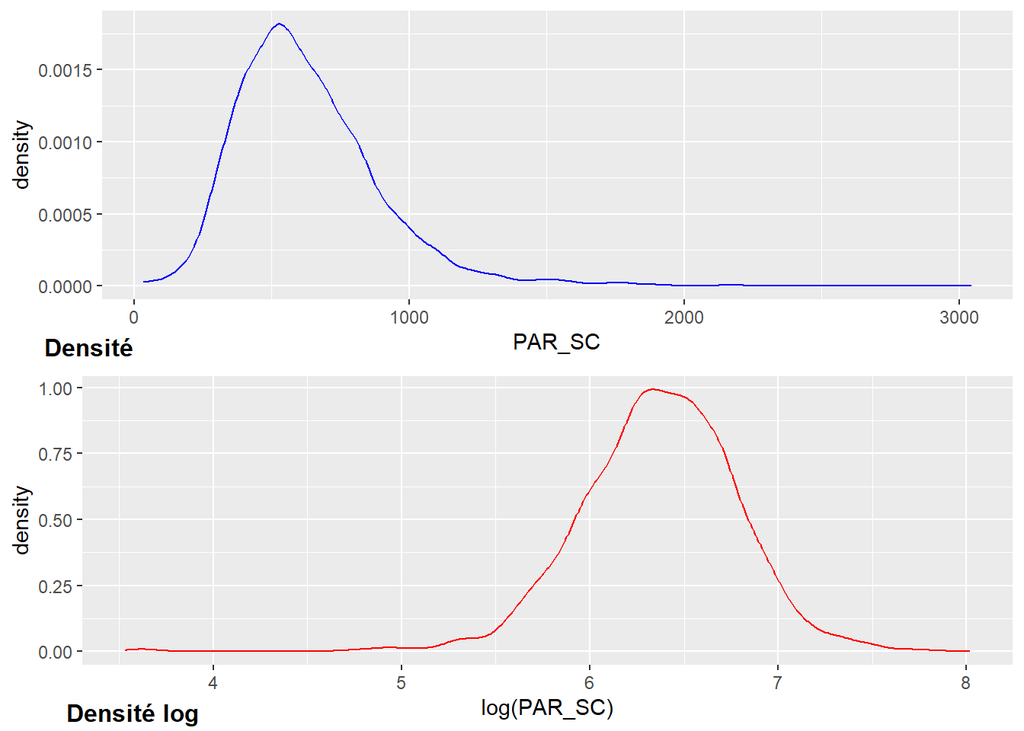

```r
density_plot = function(X,xlab,lxlab){
  density<-ggplot(data,aes(x=X))+geom_density(col="blue")+xlab(xlab)
  log_density<-ggplot(data,aes(x=log(X)))+geom_density(col="red")+xlab(lxlab)
  plot_grid(density,log_density,labels=c("Densité","Densité log"),label_size=12,ncol=1,label_x = 0, label_y = 0,hjust = -0.5, vjust = -0.5)
}

density_plot(data$PAR_SC,xlab="PAR_SC",lxlab="log(PAR_SC)")
```

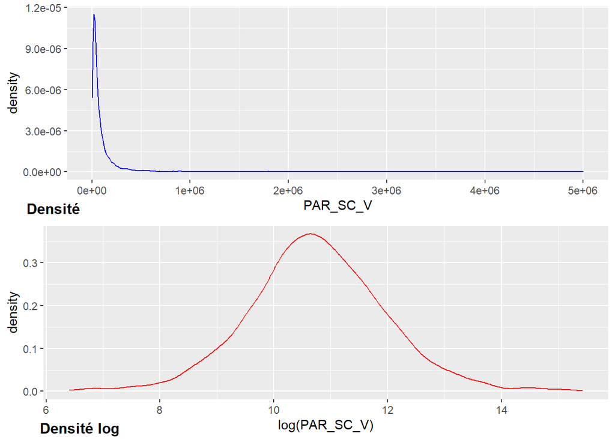

```r
density_plot(data$PAR_SC_V,xlab="PAR_SC_V",lxlab="log(PAR_SC_V)")
```

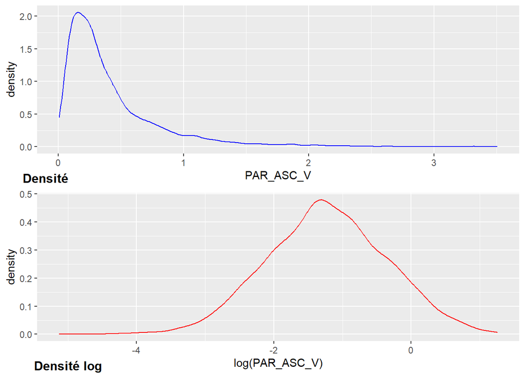

```r
density_plot(data$PAR_ASC_V,xlab="PAR_ASC_V",lxlab="log(PAR_ASC_V)")
```

On leur applique donc une transformation log.

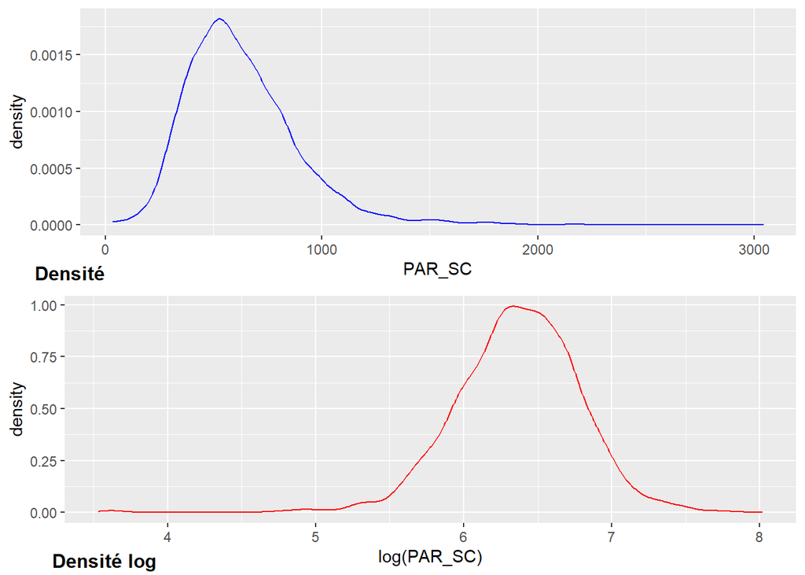

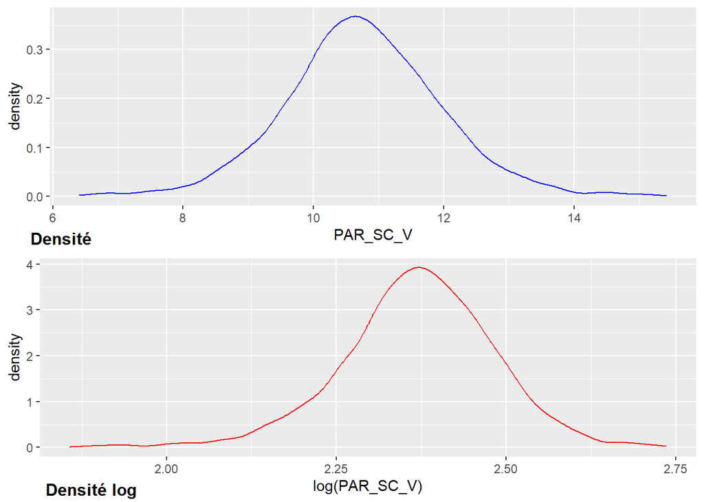

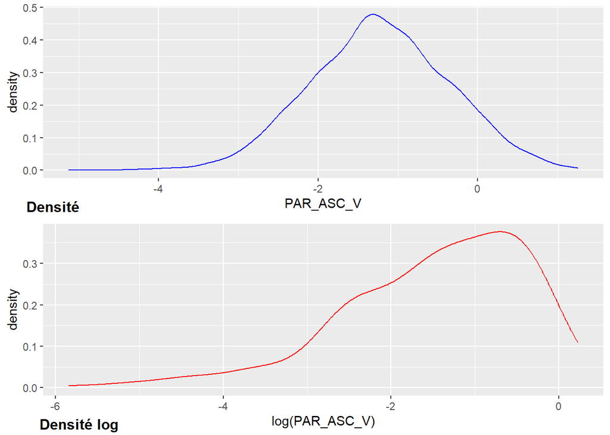

### Variables très corrélées

```r
corr <- cor(x=data[,-p])

#selection des indices de la matrice de correlation > 0.99
high.corr.index.new <- which(corr > 0.99, arr.ind = TRUE) %>% unname

#selection des indices appartenant a la matrice triangulaire inferieure stricte,
#pour retirer les doublons, ainsi que les elements diagonaux.
lower.tri <- lower.tri(corr, diag=FALSE)
high.corr.index.new <- high.corr.index.new[which(lower.tri[high.corr.index.new]==TRUE),]
high.corr.index.new
```

```
##      [,1] [,2]
## [1,]   37   36
## [2,]   72   71
## [3,]  164  160
```

Nom des variables corrélées:

```r
correlated.variables <- matrix(c(names(data)[high.corr.index.new[,1]],
                         names(data)[high.corr.index.new[,2]]), nrow=nrow(high.corr.index.new))
correlated.variables
```

```
##      [,1]                [,2]
## [1,] "PAR_ASE34"         "PAR_ASE33"
## [2,] "PAR_ASEV34"        "PAR_ASEV33"
## [3,] "PAR_ZCD_10FR_MEAN" "PAR_ZCD"
```

On remarque que les deux premiers couples de variables très corrélées sont en fait les deux dernières mesures associées respectivement aux variables PAR_ASE et PAR_ASEV.

Le dernier couple de corrélation très élevée montre que la variable *PAR_ZCD* est très corrélée avec *PAR_ZCD_10FR_MEAN* dont le nom semble qu’il s’agit d’une moyenne des *PAR_ZCD*.

On veillera à bien retirer à chaque fois l’une des deux variables très corrélées, en effet les garder augmenterait la dimmension et la complexité du modèle, sans pour autant apporter de l’information utile.

On retirera par exemple les variables *PAR_ASE34*, *PAR_ASEV34* et *PAR_ZCD_10FR_MEAN*.

```r
data <- data[,-high.corr.index.new[,1]]
n <- nrow(data)
p <- ncol(data)

dim(data)
```

```
## [1] 4278  169
```

Il reste bien 169 variables pour 4278 vecteurs de données.

### Cas des variables *PAR_ASE_M*, *PAR_ASE_MV*, *PAR_SFM_M* et *PAR_SFM_MV*

```r
#indices <- which(colnames(data) %in% c("PAR_ASE_M", "PAR_ASE_MV", "PAR_SFM_M", "PAR_SFM_MV"))

#data <- data[, -indices]
#n <- nrow(data)
#p <- ncol(data)
#dim(data)
```

## Echantillon d’apprentissage

Dans le but de continuer notre analyse et de pouvoir utiliser la fonction glm par la suite, il nous faut créer une variable catégorielle y qui prenne comme valeur uniquement 0 et 1 selon le genre de l’échantillon. On choisira donc arbitrairement le Jazz vaut 1 et le classique vaut 0.

```r
set.seed(103)
train=sample(c(TRUE,FALSE),n,rep=TRUE,prob=c(2/3,1/3))

x <- data[, -p]
y <- ifelse(data$GENRE=="Jazz", 1, 0)

train = sample(c(TRUE,FALSE), n, rep=TRUE, prob=c(2/3,1/3))
x.train <- x[which(train),]
x.test <- x[which(train==FALSE),]

y.train <- y[which(train)]
y.test <- y[which(train==FALSE)]

data.train <- cbind(x.train, y=y.train)
data.test <- cbind(x.test, y=y.test)

n.train <- nrow(data.train)
p.train <- ncol(data.train)

n.test <- nrow(data.test)
p.test <- ncol(data.test)

dim(data.train)
```

```
## [1] 2815  169
```

```r
dim(data.test)
```

```
## [1] 1463  169
```

## Estimation de modèle

On commence par créer nos différents modèles à l’aide de la fonction glm du package stats.

```r
## Définition de Mod0
Mod0 <- glm(y~PAR_TC+PAR_SC+PAR_SC_V+PAR_ASE_M,PAR_ASE_MV+PAR_SFM_M+PAR_SFM_MV, family=binomial, data=data.train)
summary(Mod0)
```

```
##
## Call:
## glm(formula = y ~ PAR_TC + PAR_SC + PAR_SC_V + PAR_ASE_M, family = binomial,
##     data = data.train, weights = PAR_ASE_MV + PAR_SFM_M + PAR_SFM_MV)
##
## Deviance Residuals:
##     Min       1Q   Median       3Q      Max
## -0.4755  -0.2567  -0.1710   0.2640   0.7065
##
## Coefficients:
##               Estimate Std. Error z value Pr(>|z|)
## (Intercept)  4.069e+01  2.158e+01   1.886 0.059318 .
## PAR_TC       1.696e-01  4.923e-01   0.345 0.730406
## PAR_SC      -2.275e-03  8.964e-04  -2.538 0.011146 *
## PAR_SC_V     6.939e-01  1.980e-01   3.504 0.000458 ***
## PAR_ASE_M    2.892e+02  1.351e+02   2.142 0.032233 *
## ---
## Signif. codes:  0 '***' 0.001 '**' 0.01 '*' 0.05 '.' 0.1 ' ' 1
##
## (Dispersion parameter for binomial family taken to be 1)
##
##     Null deviance: 232.42  on 2814  degrees of freedom
## Residual deviance: 215.16  on 2810  degrees of freedom
## AIC: 10
##
## Number of Fisher Scoring iterations: 4
```

```r
## Définition de ModT
ModT <- glm(y~., family=binomial, data=data.train)
summary(ModT)
```

```
##
## Call:
## glm(formula = y ~ ., family = binomial, data = data.train)
##
## Deviance Residuals:
##     Min       1Q   Median       3Q      Max
## -3.1770  -0.1666  -0.0089   0.0671   3.1474
##
## Coefficients:
##                          Estimate Std. Error z value Pr(>|z|)
## (Intercept)             2.690e+02  8.586e+01   3.133 0.001730 **
## PAR_TC                 -2.206e-01  3.056e-01  -0.722 0.470382
## PAR_SC                  1.188e-02  5.282e-03   2.250 0.024462 *
## PAR_SC_V                7.858e-01  3.209e-01   2.449 0.014331 *
## PAR_ASE1                4.505e+03  6.467e+02   6.965 3.27e-12 ***
## PAR_ASE2                4.892e+03  6.473e+02   7.557 4.14e-14 ***
## PAR_ASE3                4.537e+03  6.415e+02   7.073 1.52e-12 ***
## PAR_ASE4                4.842e+03  6.580e+02   7.358 1.87e-13 ***
## PAR_ASE5                4.554e+03  6.393e+02   7.123 1.05e-12 ***
## PAR_ASE6                4.708e+03  6.525e+02   7.215 5.38e-13 ***
## PAR_ASE7                4.643e+03  6.437e+02   7.214 5.44e-13 ***
## PAR_ASE8                4.668e+03  6.462e+02   7.224 5.06e-13 ***
## PAR_ASE9                4.672e+03  6.450e+02   7.244 4.36e-13 ***
## PAR_ASE10               4.688e+03  6.455e+02   7.263 3.79e-13 ***
## PAR_ASE11               4.644e+03  6.450e+02   7.200 6.04e-13 ***
## PAR_ASE12               4.745e+03  6.470e+02   7.334 2.24e-13 ***
## PAR_ASE13               4.673e+03  6.462e+02   7.231 4.78e-13 ***
## PAR_ASE14               4.626e+03  6.467e+02   7.152 8.53e-13 ***
## PAR_ASE15               4.619e+03  6.450e+02   7.161 8.00e-13 ***
## PAR_ASE16               4.584e+03  6.426e+02   7.134 9.72e-13 ***
## PAR_ASE17               4.632e+03  6.457e+02   7.174 7.26e-13 ***
## PAR_ASE18               4.688e+03  6.452e+02   7.266 3.71e-13 ***
## PAR_ASE19               4.753e+03  6.460e+02   7.358 1.87e-13 ***
## PAR_ASE20               4.566e+03  6.436e+02   7.094 1.30e-12 ***
## PAR_ASE21               4.665e+03  6.465e+02   7.216 5.36e-13 ***
## PAR_ASE22               4.775e+03  6.481e+02   7.368 1.73e-13 ***
## PAR_ASE23               4.781e+03  6.499e+02   7.357 1.89e-13 ***
## PAR_ASE24               4.769e+03  6.472e+02   7.368 1.73e-13 ***
## PAR_ASE25               4.649e+03  6.481e+02   7.174 7.30e-13 ***
## PAR_ASE26               4.545e+03  6.469e+02   7.026 2.12e-12 ***
```

[output cut: 134 more lines]

```
## PAR_1RMS_TCD_10FR_VAR   1.391e+01  6.554e+02   0.021 0.983066
## PAR_2RMS_TCD_10FR_MEAN -4.760e+02  2.325e+02  -2.047 0.040652 *
## PAR_2RMS_TCD_10FR_VAR  -4.590e+03  2.371e+03  -1.936 0.052838 .
## PAR_3RMS_TCD_10FR_MEAN  4.260e+02  3.787e+02   1.125 0.260675
## PAR_3RMS_TCD_10FR_VAR   8.465e+03  6.580e+03   1.286 0.198329
## ---
## Signif. codes:  0 '***' 0.001 '**' 0.01 '*' 0.05 '.' 0.1 ' ' 1
##
## (Dispersion parameter for binomial family taken to be 1)
##
##     Null deviance: 3891.53  on 2814  degrees of freedom
## Residual deviance:  904.97  on 2646  degrees of freedom
## AIC: 1243
##
## Number of Fisher Scoring iterations: 9
```

```r
## On récupère les p-value des variables
p_value <- coef(summary(ModT))[-1,4]

## On sélectionne celles qui ont un niveau de significativité de 5% et on crée la formule de notre modèle Mod1
index.var.Mod1 <- which(p_value>0.05)
var.Mod1 <- names(data[index.var.Mod1])
formula.Mod1 <- as.formula(paste("y ~",paste(var.Mod1, collapse= "+")))

Mod1<-glm(formula <- formula.Mod1, family=binomial, data=data.train)

## On sélectionne celles qui ont un niveau de significativité de 20% et on crée la formule de notre modèle Mod2
index.var.Mod2 <- which(p_value>0.2)
var.Mod2 <- names(data[index.var.Mod2])
formula.Mod2 <- as.formula(paste("y ~",paste(var.Mod2, collapse= "+")))

Mod2 <- glm(formula=formula.Mod2, family=binomial, data=data.train)
library(MASS)
## Attention execution longue

#step <- stepAIC(ModT)
```

Modèle final:

```r
## Selection des variables eliminees
#removed.variables <- gsub('- ', '', step$anova$Step[-1])
#variable.names <- names(data)[-p]

## Selection des variables à garder
#keep.indices <- ifelse(variables %in% removed.variables, FALSE, TRUE) %>% which()
#variables.AIC <- variable.names[keep.indices]

## Creation de la formule
#formula.AIC <- as.formula(paste("y ~",paste(variables.AIC, collapse= "+")))
#formula.AIC
```

```r
## Modèle final
#ModAIC <- glm(formula=formula.AIC, family=binomial, data=data.train)
```

## Courbes ROC

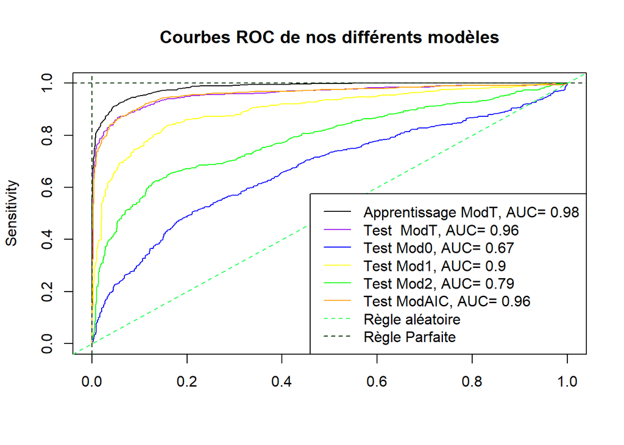

On peut alors comparer l’aire sous la courbe pour classer nos meilleures règles de décision. On constate logiquement que le les prédictions sur le jeu d’apprentissage de ModT sont très précises ce qui était attendu.

Toutefois, les performances de ModT sur les données test sont aussi très bonnes et il apparaît qu’avec ModAIC ce sont les deux meilleurs modèles.

En outre, on remarque que Mod0 est très peu performant et se rapproche d’un choix aléatoire, ceci est dû que les variables retenues sont très peu nombreuses et ne sont pas des variables intrinsèques de notre jeu de donnée (comme évoqué précédemment).

Enfin, on remarque que Mod1 et un bon modèle alors que Mod12 a des performances plutôt faibles sûrement dues au fait que l’on considère peu de variables dans ce modèle.

## Erreurs

On souhaite maintenant comparer nos modèles à l’aide de l’erreur effectuée sur l’échantillon d’apprentissage puis sur l’échantillon de test

```r
predproba_train_Mod0=predict(Mod0,type="response")
predproba_train_Mod1=predict(Mod1,type="response")
predproba_train_Mod2=predict(Mod2,type="response")
predproba_train_ModAIC=predict(ModAIC,type="response")
```

[output not shown]